# Práctica 2: Proyecto analítico. Integración, limpieza, validación y análisis

Alba Caderno Fernández - Diego García García

28 de diciembre de 2022

# 1 Detalles de la actividad

## 1.1 Descripción

El objetivo de esta actividad será el tratamiento de un dataset, que puede ser el creado en la Práctica 1 o bien cualquier dataset libre disponible en Kaggle https://www.kaggle.com.

Un ejemplo de dataset con el que podéis trabajar es el “Heart Attack Analysis & Prediction dataset”: https://www.kaggle.com/datasets/rashikrahmanpritom/heart-attack-analysis-predictiondataset

**Importante:** si se elige un dataset diferente al propuesto es importante que este contenga una amplia variedad de datos numéricos y categóricos para poder realizar un análisis más rico y poder responder a las diferentes preguntas planteadas en el enunciado de la práctica.

## 1.2 Objetivos

Los objetivos concretos de esta práctica son:

- Aprender a aplicar los conocimientos adquiridos y su capacidad de resolución de problemas en entornos nuevos o poco conocidos dentro de contextos más amplios o multidisciplinares.
- Saber identificar los datos relevantes y los tratamientos necesarios (integración, limpieza y validación) para llevar a cabo un proyecto analítico.

Aprender a analizar los datos adecuadamente para abordar la información  
contenida en los datos.

- Identificar la mejor representación de los resultados para aportar conclusiones sobre el problema planteado en el proceso analítico.
- Actuar con los principios éticos y legales relacionados con la manipulación de datos en función del ámbito de aplicación.
- Desarrollar las habilidades de aprendizaje que les permitan continuarestudiando de un modo que tendrá que ser en gran medida autodirigido o autónomo.
- Desarrollar la capacidad de búsqueda, gestión y uso de información y recursos en el ámbito de la ciencia de datos.

## 1.3 Competencias

En esta práctica se desarrollan las siguientes competencias del Máster de Data Science:

Capacidad de analizar un problema en el nivel de abstracción adecuado a cada situación y aplicar las habilidades y conocimientos adquiridos para abordarlo y resolverlo.

Capacidad para aplicar las técnicas específicas de tratamiento de datos (integración, transformación, limpieza y validación) para su posterior análisis.

# 2 Resolución

## 2.1 Descripción del dataset. ¿Por qué es importante y qué pregunta/problema pretende responder?

El Dataset escogido en el enunciado de la práctica 2 nos muestra los datos para la clasificación de ataques al corazón. Dentro del conjunto de datos nos encontramos con 14 atributos provenientes de 4 bases de datos distintas del Instituto Húngaro de Cardiología en Budapest por Andras Janosi, el Hospital Universitario, Zurich, en Suiza por William Steinbrunn, el Hospital Universitario, Basilea, en Suiza por Matthias Pfisterer y el V.A. Medical Center en Long Beach y Cleveland Clinic Foundation por Robert Detrano.

**Nota:** Tener en cuenta que en el atributo thall para el valor 0 se ha rellenado el dato con el value null por lo que puede ser necesario usar alguna técnica de ML supervisada para asignarle un valor “aproximado”.

- **Age:** Edad del paciente en años.
- **Sex:** Sexo del paciente.
- Valor 1: masculino
- Valor 0: femenino
- **cp:** Tipo de dolor en el pecho.
- Valor 0: Asintomático
- Valor 1: Angina típica
- Valor 2: Angina atípica
- Valor 3: Dolor no-anginoso
- **trtbps:** Presión arterial en reposo medida en el servicio de admisión del hospital en mm Hg. La presión sistólica.
- **chol:** Colesterol en mg/dl obtenido a través del sensor BMI
- **fbs:** Glucemia en ayunas > 120 mg/dl.
- Valor 1: Verdadero
- Valor 0: Falso
- **rest_ecg:** Resultados electrocardiográficos en reposo
- Valor 0: Normal
- Valor 1: Tener anomalías en la onda ST-T (inversiones de la onda T y/o elevación o depresión del ST > 0,05 mV)
- Valor 2: Mostrar hipertrofia ventricular izquierda probable o definitiva según los criterios de Estes.
- **thalach:** Frecuencia cardíaca máxima alcanzada.
- **exang:** Angina inducida por el ejercicio
- Valor 1: Si
- Valor 0: No
- **old peak:** Depresión del ST inducida por el ejercicio en relación con el reposo.
- **slp:** La pendiente del segmento ST de ejercicio máximo (El segmento ST representa el período isoeléctrico cuando los ventrículos se encuentran entre la despolarización y la repolarización (https://es.wikipedia.org/wiki/Segmento_ST)).
- Valor 0: Pendiente abajo
- Valor 1: Plana
- Valor 2: Pendiente arriba
- **caa:** Número de vasos principales (0-3) coloreados por fluoroscopia
- **thall:** thalassemia (Resultado de la prueba de esfuerzo con talio)
- Valor 0: null
- Valor 1: Defecto fijo
- Valor 2: Normal
- Valor 3: Defecto reversible
- **output:** Diagnóstico de enfermedad cardíaca (estado de enfermedad angiográfico). Si el valor es 1 entonces el paciente es más propenso a tener una enfermedad cardíaca mientras que si es 0 entonces la situación del paciente no es crítica. El estrechamiento del vaso es peligroso ya que es posible que la sangre no bombee a través del corazón, lo que puede provocar un paro cardíaco.
- Valor 0: < 50% estrechamiento del diámetro. Menos posibilidades de ataque al corazón.
- Valor 1: > 50% estrechamiento del diámetro. Más posibilidades de ataque al corazón.

## 2.2 Integración y selección de los datos de interés a analizar. Puede ser el resultado de adicionar diferentes datasets o una subselección útil de los datos originales, en base al objetivo que se quiera conseguir.

```r
# Carga del fichero de datos y lectura de los mismos
dt_heart <- read.csv("heart.csv", header = TRUE)
```

```r
# Visualización previa de los datos.
# Tipo de dato asignado a cada campo para hacernos una idea del conjunto.
str(dt_heart)
```

```
## 'data.frame':    303 obs. of  14 variables:
##  $ age     : int  63 37 41 56 57 57 56 44 52 57 ...
##  $ sex     : int  1 1 0 1 0 1 0 1 1 1 ...
##  $ cp      : int  3 2 1 1 0 0 1 1 2 2 ...
##  $ trtbps  : int  145 130 130 120 120 140 140 120 172 150 ...
##  $ chol    : int  233 250 204 236 354 192 294 263 199 168 ...
##  $ fbs     : int  1 0 0 0 0 0 0 0 1 0 ...
##  $ restecg : int  0 1 0 1 1 1 0 1 1 1 ...
##  $ thalachh: int  150 187 172 178 163 148 153 173 162 174 ...
##  $ exng    : int  0 0 0 0 1 0 0 0 0 0 ...
##  $ oldpeak : num  2.3 3.5 1.4 0.8 0.6 0.4 1.3 0 0.5 1.6 ...
##  $ slp     : int  0 0 2 2 2 1 1 2 2 2 ...
##  $ caa     : int  0 0 0 0 0 0 0 0 0 0 ...
##  $ thall   : int  1 2 2 2 2 1 2 3 3 2 ...
##  $ output  : int  1 1 1 1 1 1 1 1 1 1 ...
```

```r
sapply(dt_heart, function(x) class(x))
```

```
##       age       sex        cp    trtbps      chol       fbs   restecg  thalachh
## "integer" "integer" "integer" "integer" "integer" "integer" "integer" "integer"
##      exng   oldpeak       slp       caa     thall    output
## "integer" "numeric" "integer" "integer" "integer" "integer"
```

```r
summary(dt_heart)
```

```
##       age             sex               cp            trtbps
##  Min.   :29.00   Min.   :0.0000   Min.   :0.000   Min.   : 94.0
##  1st Qu.:47.50   1st Qu.:0.0000   1st Qu.:0.000   1st Qu.:120.0
##  Median :55.00   Median :1.0000   Median :1.000   Median :130.0
##  Mean   :54.37   Mean   :0.6832   Mean   :0.967   Mean   :131.6
##  3rd Qu.:61.00   3rd Qu.:1.0000   3rd Qu.:2.000   3rd Qu.:140.0
##  Max.   :77.00   Max.   :1.0000   Max.   :3.000   Max.   :200.0
##       chol            fbs            restecg          thalachh
##  Min.   :126.0   Min.   :0.0000   Min.   :0.0000   Min.   : 71.0
##  1st Qu.:211.0   1st Qu.:0.0000   1st Qu.:0.0000   1st Qu.:133.5
##  Median :240.0   Median :0.0000   Median :1.0000   Median :153.0
##  Mean   :246.3   Mean   :0.1485   Mean   :0.5281   Mean   :149.6
##  3rd Qu.:274.5   3rd Qu.:0.0000   3rd Qu.:1.0000   3rd Qu.:166.0
##  Max.   :564.0   Max.   :1.0000   Max.   :2.0000   Max.   :202.0
##       exng           oldpeak          slp             caa
##  Min.   :0.0000   Min.   :0.00   Min.   :0.000   Min.   :0.0000
##  1st Qu.:0.0000   1st Qu.:0.00   1st Qu.:1.000   1st Qu.:0.0000
##  Median :0.0000   Median :0.80   Median :1.000   Median :0.0000
##  Mean   :0.3267   Mean   :1.04   Mean   :1.399   Mean   :0.7294
##  3rd Qu.:1.0000   3rd Qu.:1.60   3rd Qu.:2.000   3rd Qu.:1.0000
##  Max.   :1.0000   Max.   :6.20   Max.   :2.000   Max.   :4.0000
##      thall           output
##  Min.   :0.000   Min.   :0.0000
##  1st Qu.:2.000   1st Qu.:0.0000
##  Median :2.000   Median :1.0000
##  Mean   :2.314   Mean   :0.5446
##  3rd Qu.:3.000   3rd Qu.:1.0000
##  Max.   :3.000   Max.   :1.0000
```

```r
typeof(dt_heart)
```

```
## [1] "list"
```

```r
#install.packages("ggplot2")
library(purrr)
library(tidyr)
library(ggplot2)
```

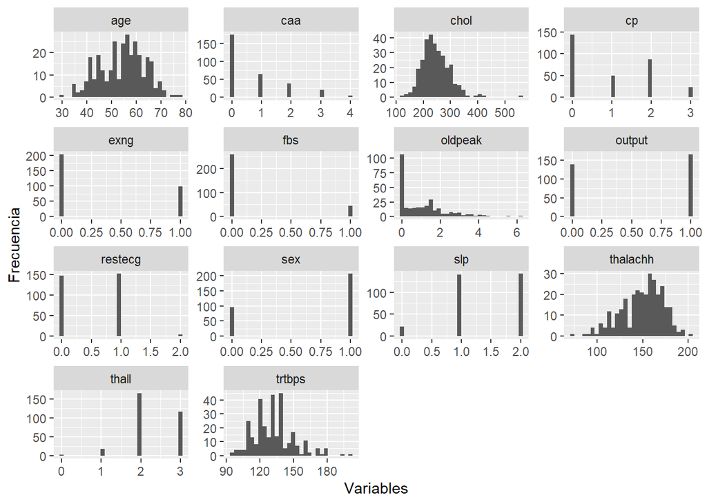

```r
# Se realiza un estudio visual de todas las variables para analizar sus distribuciones así como posibles interpretaciones iniciales.
dt_heart %>%
  keep(is.numeric) %>%
  gather() %>%
  ggplot(aes(value)) +
    facet_wrap(~ key, scales = "free") +
    labs(x="Variables",y= "Frecuencia")  +
    geom_histogram()
```

En base a los resultados obtenidos, del conjunto de datos, podemos obtener una relación de primeras ideas como:

- La asignación automática de tipo de datos de R al conjunto se basa en valores enteros y numéricos.
- Los pacientes de estudio se sitúan en edades comprendidas entre los 29 y los 77 años diendo la media de 54 años.
- Existe más cantidad de personas con sexo masculino que con femenino.
- Una minoría de las personas de estudio presenta dolor no-anginoso frente a la mayoría que son asintomáticos.
- La presión sistólica de los pacientes se centra en torno a los 130mm Hg.
- La distribución de los datos de la variable colesterol presenta cierta cola a la derecha por lo que los datos se concentrando en torno a los 250 mg/dl.
- La mayoría de los pacientes no presenta glucemia en ayunas por encima de los 120 mg/dl
- La mayoría de los pacientes no presenta angina inducida por el ejercicio

## 2.3 Limpieza de los datos.

### 2.3.1 ¿Los datos contienen ceros o elementos vacíos? Gestiona cada uno de estos casos.

```r
# Verificar que no existen elementos NA.
sapply(dt_heart, function(x) sum(is.na(x)))
```

```
##      age      sex       cp   trtbps     chol      fbs  restecg thalachh
##        0        0        0        0        0        0        0        0
##     exng  oldpeak      slp      caa    thall   output
##        0        0        0        0        0        0
```

```r
# Verificar en base a la descripción de los atributos los valores distintos de cada uno de ellos para detectar aquellos que sean neesarios tratar.
sapply(dt_heart, function(x) unique(x))
```

```
## $age
##  [1] 63 37 41 56 57 44 52 54 48 49 64 58 50 66 43 69 59 42 61 40 71 51 65 53 46
## [26] 45 39 47 62 34 35 29 55 60 67 68 74 76 70 38 77
##
## $sex
## [1] 1 0
##
## $cp
## [1] 3 2 1 0
##
## $trtbps
##  [1] 145 130 120 140 172 150 110 135 160 105 125 142 155 104 138 128 108 134 122
## [20] 115 118 100 124  94 112 102 152 101 132 148 178 129 180 136 126 106 156 170
## [39] 146 117 200 165 174 192 144 123 154 114 164
##
## $chol
##   [1] 233 250 204 236 354 192 294 263 199 168 239 275 266 211 283 219 340 226
##  [19] 247 234 243 302 212 175 417 197 198 177 273 213 304 232 269 360 308 245
##  [37] 208 264 321 325 235 257 216 256 231 141 252 201 222 260 182 303 265 309
##  [55] 186 203 183 220 209 258 227 261 221 205 240 318 298 564 277 214 248 255
##  [73] 207 223 288 160 394 315 246 244 270 195 196 254 126 313 262 215 193 271
##  [91] 268 267 210 295 306 178 242 180 228 149 278 253 342 157 286 229 284 224
## [109] 206 167 230 335 276 353 225 330 290 172 305 188 282 185 326 274 164 307
## [127] 249 341 407 217 174 281 289 322 299 300 293 184 409 259 200 327 237 218
## [145] 319 166 311 169 187 176 241 131
##
## $fbs
## [1] 1 0
##
## $restecg
## [1] 0 1 2
##
## $thalachh
##  [1] 150 187 172 178 163 148 153 173 162 174 160 139 171 144 158 114 151 161 179
## [20] 137 157 123 152 168 140 188 125 170 165 142 180 143 182 156 115 149 146 175
## [39] 186 185 159 130 190 132 147 154 202 166 164 184 122 169 138 111 145 194 131
## [58] 133 155 167 192 121  96 126 105 181 116 108 129 120 112 128 109 113  99 177
## [77] 141 136  97 127 103 124  88 195 106  95 117  71 118 134  90
##
## $exng
## [1] 0 1
##
## $oldpeak
##  [1] 2.3 3.5 1.4 0.8 0.6 0.4 1.3 0.0 0.5 1.6 1.2 0.2 1.8 1.0 2.6 1.5 3.0 2.4 0.1
## [20] 1.9 4.2 1.1 2.0 0.7 0.3 0.9 3.6 3.1 3.2 2.5 2.2 2.8 3.4 6.2 4.0 5.6 2.9 2.1
## [39] 3.8 4.4
##
## $slp
## [1] 0 2 1
##
## $caa
## [1] 0 2 1 3 4
##
## $thall
## [1] 1 2 3 0
##
## $output
## [1] 1 0
```

**Como se aprecia en los resultados obtenidos será necesario tratar el atributo:**

- **thall:** ya que en un apartado anterior, en el que se describe el dataset, se ha puntualizado que existen valores 0 que hacen referencia a un valor “null” y en concreto son dos observaciones. Por tanto, para dar sentido a estos valores se usará un método de imputación de valores basado en la similitud o diferencia entre los registros. Se usará kNN imputation ya que damos por hecho que los registros están relacionados. Igualmente siempre será mejor tratar los resultados de análisis de datos cercanos frente a datos vacíos.
- **caa: se aprecia un valor fuera del rango definido. Dicho valor es el 4 que se tratará como un NA y se procederá de la misma manera que para el atributo anterior.**

```r
suppressWarnings(suppressMessages(library(VIM)))
dt_heart$thall[dt_heart$thall == 0] <- NA # Sustituir valor 0(null) por NA
dt_heart$caa[dt_heart$caa == 4] <- NA # Sustituir valor 0(null) por NA
dt_heart$thall <- kNN(dt_heart)$thall
dt_heart$caa <- kNN(dt_heart)$caa
unique(dt_heart$thall)
```

```
## [1] 1 2 3
```

```r
unique(dt_heart$caa)
```

```
## [1] 0 2 1 3
```

### 2.3.2 Identifica y gestiona los valores extremos.

Para poder visualizar de una manera rápida y sencilla para el humano realizamos un boxplot o gráfico de caja.

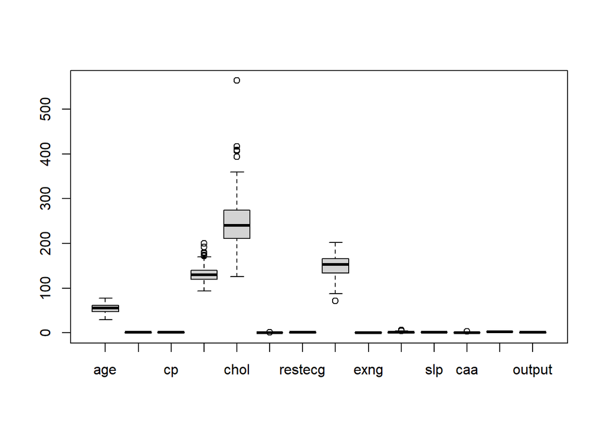

```r
boxplot(dt_heart)
```

```r
print("Val. extr. trtbps")
```

```
## [1] "Val. extr. trtbps"
```

```r
boxplot.stats(dt_heart$trtbps)$out
```

```
## [1] 172 178 180 180 200 174 192 178 180
```

```r
print("Val. extr. chol")
```

```
## [1] "Val. extr. chol"
```

```r
boxplot.stats(dt_heart$chol)$out
```

```
## [1] 417 564 394 407 409
```

```r
print("Val. extr. thalach")
```

```
## [1] "Val. extr. thalach"
```

```r
boxplot.stats(dt_heart$thalach)$out
```

```
## [1] 71
```

```r
print("Val. extr. oldpeak")
```

```
## [1] "Val. extr. oldpeak"
```

```r
boxplot.stats(dt_heart$oldpeak)$out
```

```
## [1] 4.2 6.2 5.6 4.2 4.4
```

```r
print("Val. extr. caa")
```

```
## [1] "Val. extr. caa"
```

```r
boxplot.stats(dt_heart$caa)$out
```

```
##  [1] 3 3 3 3 3 3 3 3 3 3 3 3 3 3 3 3 3 3 3 3
```

Para el análisis de estudio no se tratarán estos valores como extremos ya que a pesar de ser cierto que se alejan de la media, son valores que se consideran reales y deben ser tratados en el estudio. Eliminarlos provocaría distorsión en la interpretación de los resultados.

## 2.4 Análisis de los datos.

### 2.4.1 Selección de los grupos de datos que se quieren analizar/comparar (p.ej., si se van a comparar grupos de datos, ¿cuáles son estos grupos y qué tipo de análisis se van a aplicar?)

Indistintamente de la creación de los grupos será muy interesante realizar un análisis de la correlación entre las variables del conjunto de datos para poder obtener más información sobre su comportamiento.

```r
# Grupo1
dt_heart_glucemia <- dt_heart[dt_heart$fbs == 1, ]
str(dt_heart_glucemia)
```

```
## 'data.frame':    45 obs. of  14 variables:
##  $ age     : int  63 52 58 61 59 65 53 54 71 58 ...
##  $ sex     : int  1 1 0 1 1 0 1 0 0 1 ...
##  $ cp      : int  3 2 3 2 2 2 2 2 2 2 ...
##  $ trtbps  : int  145 172 150 150 150 140 130 135 110 140 ...
##  $ chol    : int  233 199 283 243 212 417 197 304 265 211 ...
##  $ fbs     : int  1 1 1 1 1 1 1 1 1 1 ...
##  $ restecg : int  0 1 0 1 1 0 0 1 0 0 ...
##  $ thalachh: int  150 162 162 137 157 157 152 170 130 165 ...
##  $ exng    : int  0 0 0 1 0 0 0 0 0 0 ...
##  $ oldpeak : num  2.3 0.5 1 1 1.6 0.8 1.2 0 0 0 ...
##  $ slp     : int  0 2 2 1 2 2 0 2 2 2 ...
##  $ caa     : int  0 0 0 0 0 1 0 0 1 0 ...
##  $ thall   : int  1 3 2 2 2 2 2 2 2 2 ...
##  $ output  : int  1 1 1 1 1 1 1 1 1 1 ...
```

### 2.4.2 Comprobación de la normalidad y homogeneidad de la varianza.

Para comprobar la normalidad de los distintos atributos que conforman el dataset se analizará una por una, con el fin de aplicar el estudio a aquellas que presenten normalidad. Se aplicarán distintas pruebas de normalidad sobre los datos siendo éstas:

- Anderson-Darling: Estudio de bondad de ajuste que mide el área entre la línea ajustada y la función de distribución empírica.
- Lilliefors: Es una mejora de la prueba de Kolomogorov-Smirnov y se recomienda usar en conjunto de datos de más de 50 observaciones.

```r
# Identificar normalidad en variables del Dataset
library(nortest)
alpha = 0.05
col.names = colnames(dt_heart)
for (i in 1:ncol(dt_heart)) {
  if (i == 1) cat("Variables que no siguen una distribución normal mediante la 'Prueba de Anderson-Darling':\n")
  if (is.integer(dt_heart[,i]) | is.numeric(dt_heart[,i])) {
    p_val = ad.test(dt_heart[,i])$p.value
    if (p_val < alpha) {
      cat(col.names[i])
      # Format output
      if ( (i < ncol(dt_heart) - 1) | (i == ncol(dt_heart)-1) ) cat(", ")
      if (i %% 5 == 0) cat("\n")
    }
  }
}
```

```
## Variables que no siguen una distribución normal mediante la 'Prueba de Anderson-Darling':
## age, sex, cp, trtbps, chol,
## fbs, restecg, thalachh, exng, oldpeak,
## slp, caa, thall, output
```

```r
library(nortest)
alpha = 0.05
col.names = colnames(dt_heart)
for (i in 1:ncol(dt_heart)) {
  if (i == 1) cat("Variables que no siguen una distribución normal mediante la 'Prueba de Lilliefors ':\n")
  if (is.integer(dt_heart[,i]) | is.numeric(dt_heart[,i])) {
    p_val = lillie.test(dt_heart[,i])$p.value
    if (p_val < alpha) {
      cat(col.names[i])
      # Format output
      if ( (i < ncol(dt_heart) - 1) | (i == ncol(dt_heart)-1) ) cat(", ")
      if (i %% 5 == 0) cat("\n")
    }
  }
}
```

```
## Variables que no siguen una distribución normal mediante la 'Prueba de Lilliefors ':
## age, sex, cp, trtbps, chol,
## fbs, restecg, thalachh, exng, oldpeak,
## slp, caa, thall, output
```

Si nos apoyamos tanto en las gráficas de las variables mostradas en un apartado anterior y en la evaluación de los resultados de las pruebas de Anderson-Darling y Lilliefors (para un nivel de significación de 0.05 se ha obtenido p-values inferioriores) podemos afirmar la ausencia de normalidad en los datos de estudio. Definir la ausencia o no, de normalidad es básico para las futuras pruebas estadísticas o modelos de regresión.